# Set 4 of Exercises

Braulio Güémez

4/10/2021

# Exercises for Chapter 4 - Bayes Rules!

```r
library(bayesrules)
library(tidyverse)
library(janitor)
```

```r
library(ggthemes)
library(ggplot2)
library(ggpubr)
```

## 4.1.

1. Since a = b, then pi =.5
2. Since a > b, then pi would be somewhat > .5
3. Since a < b by a lot, then pi would be strongly favoring < .5
4. Since a < b by not much, then then pi would be somewhat favoring < .5
5. Since a > b by a lot, then pi would be strongly favoring > .5

## 4.2

The prior is skewed to the left, so a must be LESS than B. The likelihood function is centered at pi = .50 so

the only function that satisfies those two is Option e:

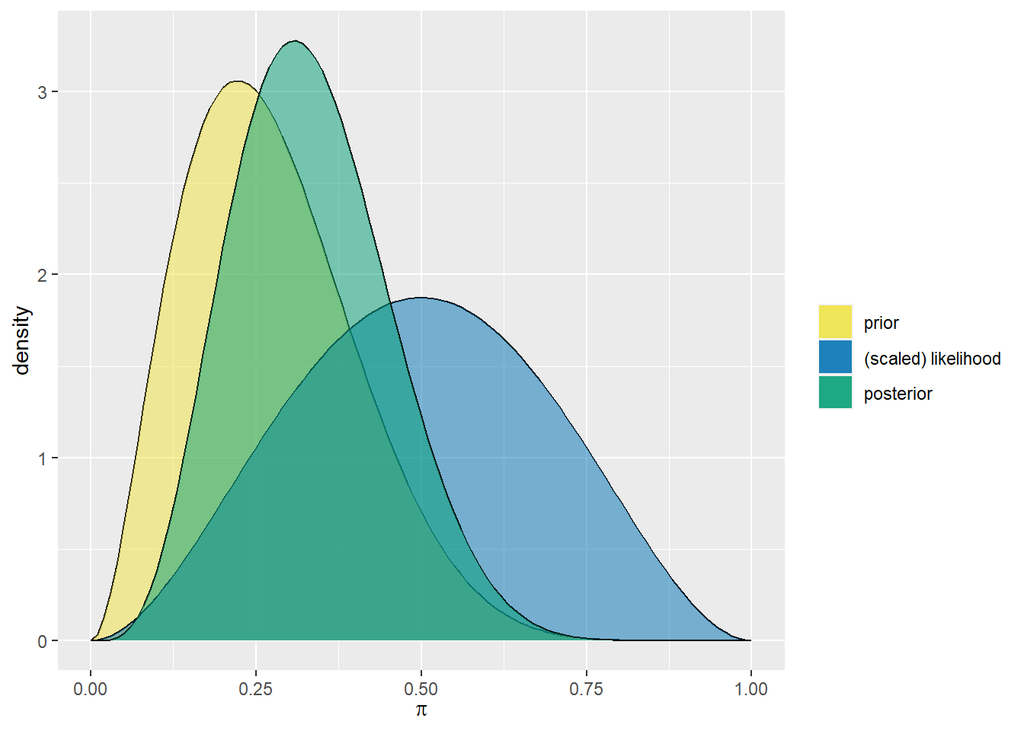

```r
plot_beta_binomial(3,8,2,4)
```

## 4.3

1. Pi must be close to zero

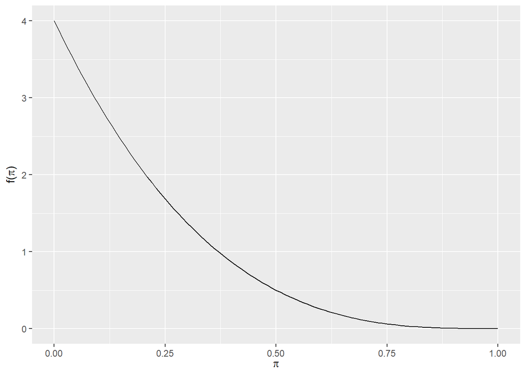

```r
plot_beta(1,4)
```

2. Anything can be possible

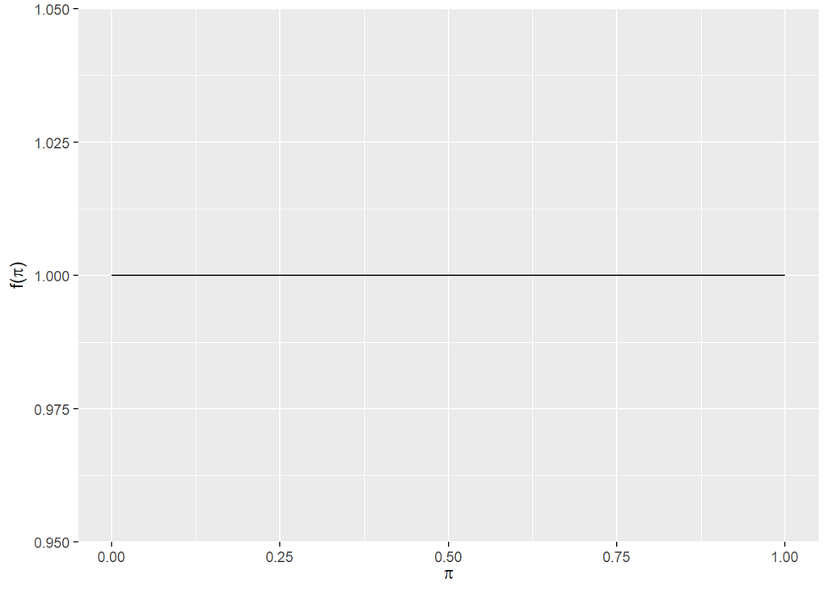

```r
plot_beta(1,1)
```

3. Pi must be close to 1

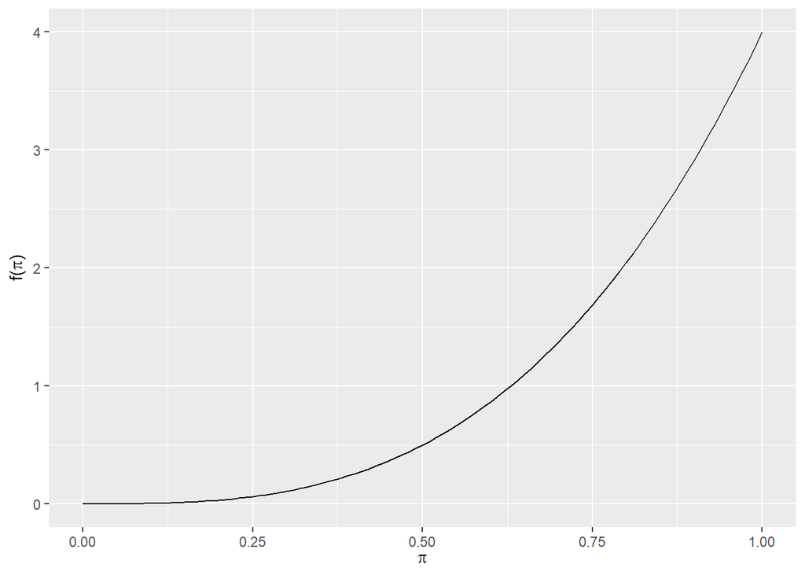

```r
plot_beta(4,1)
```

d. Pi must be more than .50 but less than Katie’s prior

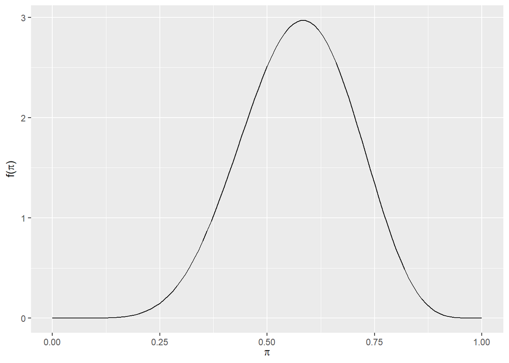

```r
plot_beta(8,6)
```

5. Pi must be less than .50 but not as much as Ben’s prior

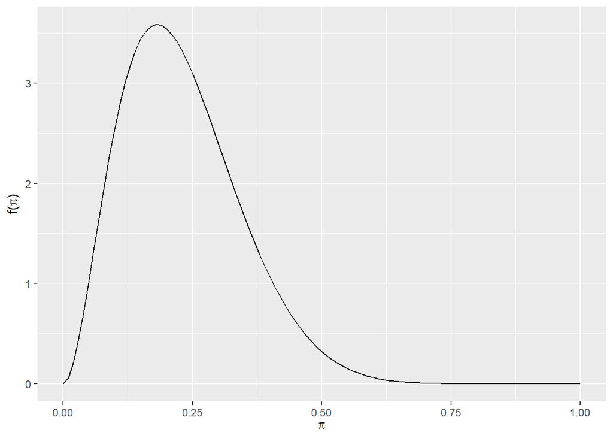

```r
plot_beta(3,10)
```

## 4.4

Kimya thinks that chances are low but she is unsure Fernando thinks that the shop is most likely to be closed. Clara thinks that the chances are low but she is not as sure as Fernando Taylor thinks that the shop will definitely be open.

## 4.5.

Kimya

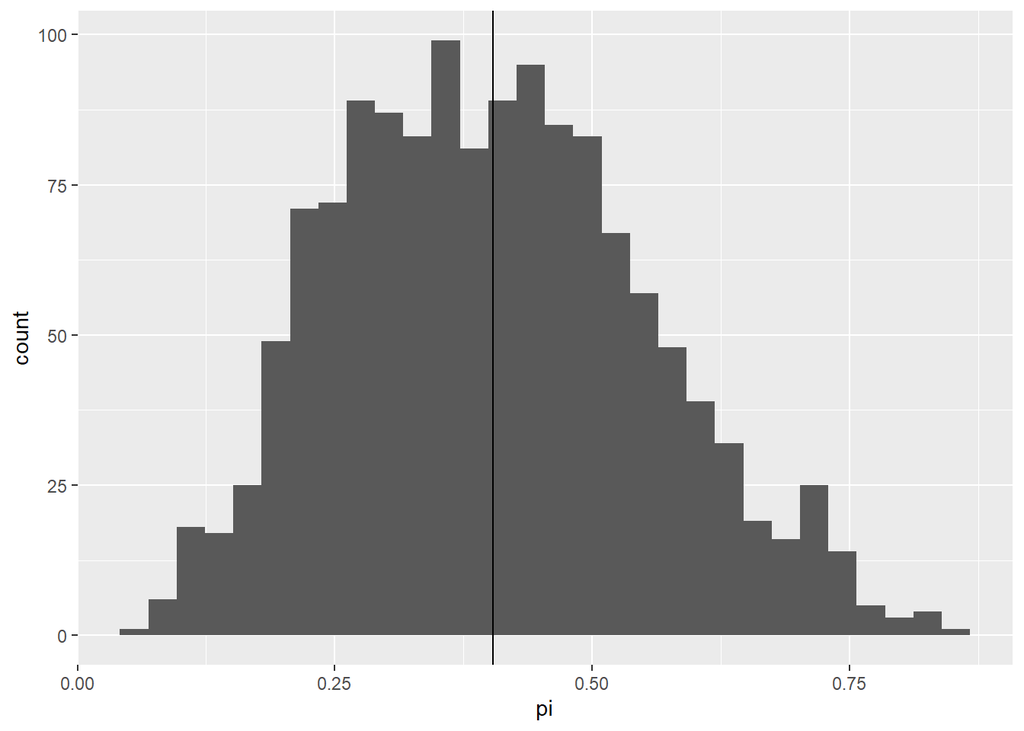

```r
set.seed(84735)

# #Prior

kim_sim <- data.frame(pi = rbeta(10000, 1, 2)) %>% ## This is the prior
  mutate(y = rbinom(10000, size = 7, prob = pi)) ## This is the potential number of opened days according to the prior

## Posterior

# Keep only the simulated pairs that match our data
kim_sim_p <- kim_sim %>%
  filter(y == 3)

# Plot the remaining pi values
kim_p <-  ggplot(kim_sim_p, aes(x = pi)) +
  geom_histogram() + geom_vline(xintercept = mean(kim_sim_p$pi))

kim_p
```

```r
## Approximate posterior

mean(kim_sim_p$pi)
```

```
## [1] 0.4034074
```

Fernando

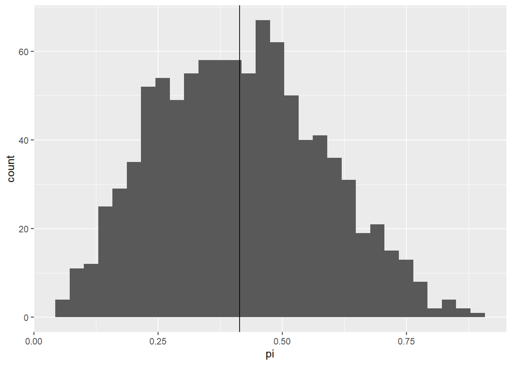

```r
set.seed(84735)

# #Prior

fer_sim <- data.frame(pi = rbeta(10000, .5, 1)) %>% ## This is the prior
  mutate(y = rbinom(10000, size = 7, prob = pi)) ## This is the potential number of opened days according to the prior

## Posterior

# Keep only the simulated pairs that match our data: 3 days
fer_sim_p <- fer_sim %>%
  filter(y == 3)

# Plot the remaining pi values
fer_p <-  ggplot(fer_sim_p, aes(x = pi)) +
  geom_histogram() + geom_vline(xintercept = mean(fer_sim_p$pi))

fer_p
```

```r
## Approximate posterior

mean(fer_sim_p$pi)
```

```
## [1] 0.4140852
```

Ciara

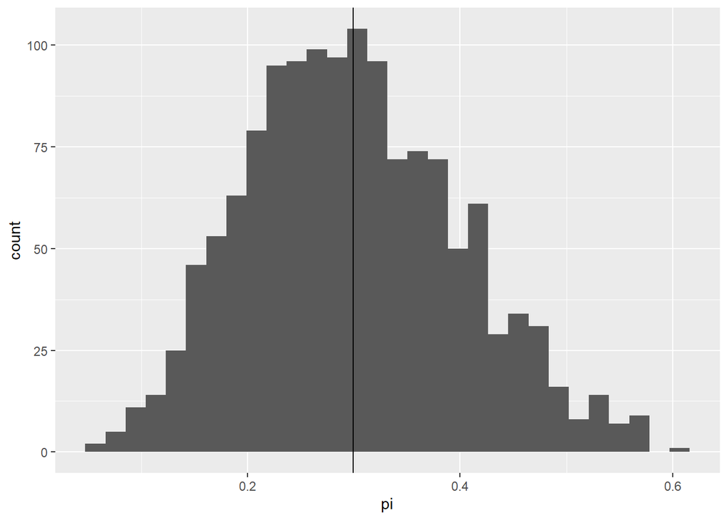

```r
set.seed(84735)

# #Prior

ci_sim <- data.frame(pi = rbeta(10000, 3, 10)) %>% ## This is the prior
  mutate(y = rbinom(10000, size = 7, prob = pi)) ## This is the potential number of opened days according to the prior

## Posterior

# Keep only the simulated pairs that match our data: 3 days
ci_sim_p <- ci_sim %>%
  filter(y == 3)

# Plot the remaining pi values
ci_p <- ggplot(ci_sim_p, aes(x = pi)) +
  geom_histogram() + geom_vline(xintercept = mean(ci_sim_p$pi))
ci_p
```

```r
## Approximate posterior

mean(ci_sim_p$pi)
```

```
## [1] 0.2993225
```

Taylor

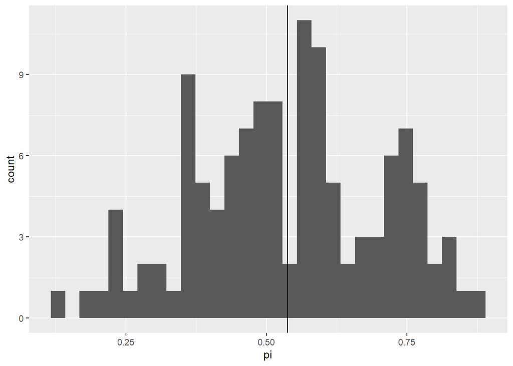

```r
set.seed(84735)

# #Prior

ty_sim <- data.frame(pi = rbeta(10000, 2, .1)) %>% ## This is the prior
  mutate(y = rbinom(10000, size = 7, prob = pi)) ## This is the potential number of opened days according to the prior

## Posterior

# Keep only the simulated pairs that match our data: 3 days
ty_sim_p <- ty_sim %>%
  filter(y == 3)

# Plot the remaining pi values
ty_p <- ggplot(ty_sim_p, aes(x = pi)) +
  geom_histogram() + geom_vline(xintercept = mean(ty_sim_p$pi))

ty_p
```

```r
## Approximate posterior

mean(ty_sim_p$pi)
```

```
## [1] 0.53744
```

## 4.6

Kim

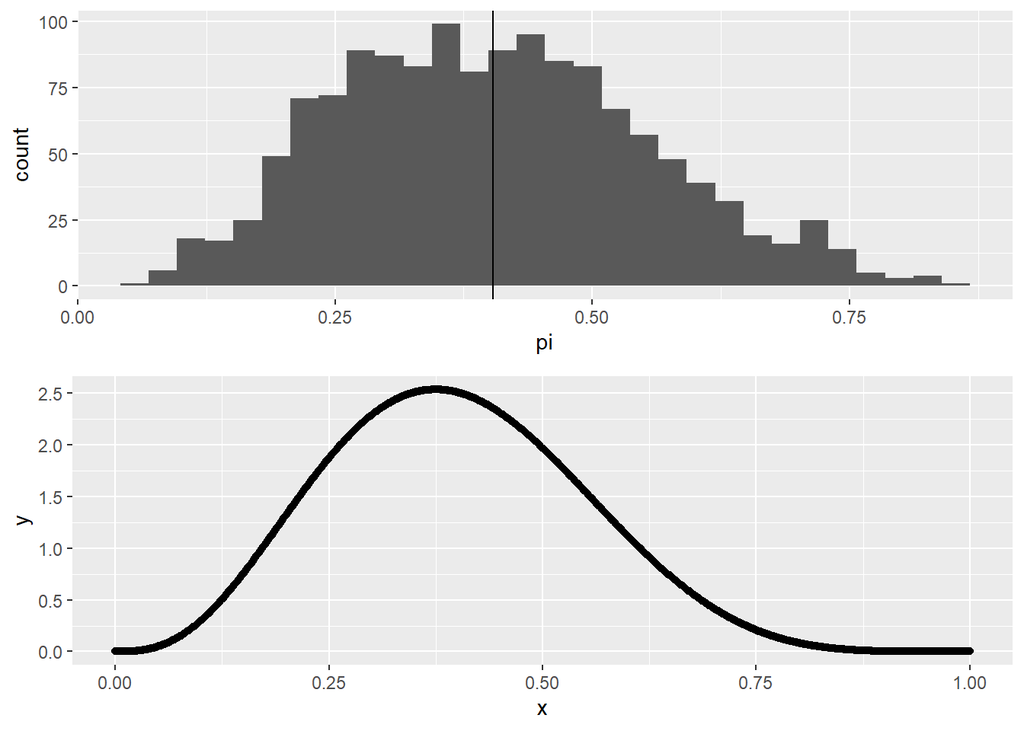

```r
x <- seq(0,1,length.out=1000) # all possible x values
posterior_kim <-tibble(x=x, y=dbeta(x, 1+3,2+7-3)) # posterior model
kim_pr <- ggplot(data=posterior_kim, aes(x,y)) + geom_point()

ggarrange(kim_p, kim_pr, ncol = 1, nrow = 2)
```

```r
## Compare means
tibble(real_mean=mean(posterior_kim$x*posterior_kim$y), simulated_mean=mean(kim_sim_p$pi))
```

```
## # A tibble: 1 x 2
##   real_mean simulated_mean
##       <dbl>          <dbl>
## 1     0.400          0.403
```

Fernando

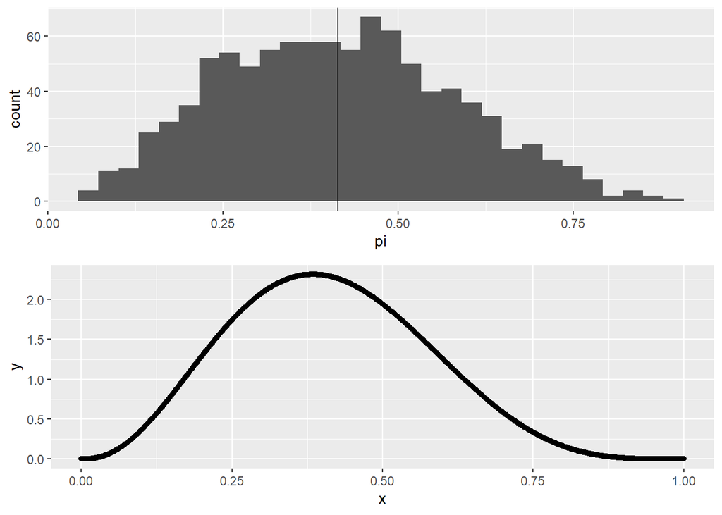

```r
x <- seq(0,1,length.out=1000) # all possible x values
posterior_fer <-tibble(x=x, y=dbeta(x, .5+3,1+7-3)) # posterior model
fer_pr <- ggplot(data=posterior_fer, aes(x,y)) + geom_point()

ggarrange(fer_p, fer_pr, ncol = 1, nrow = 2)
```

```r
## Compare means
tibble(real_mean=mean(posterior_fer$x*posterior_fer$y), simulated_mean=mean(fer_sim_p$pi))
```

```
## # A tibble: 1 x 2
##   real_mean simulated_mean
##       <dbl>          <dbl>
## 1     0.411          0.414
```

Ciara

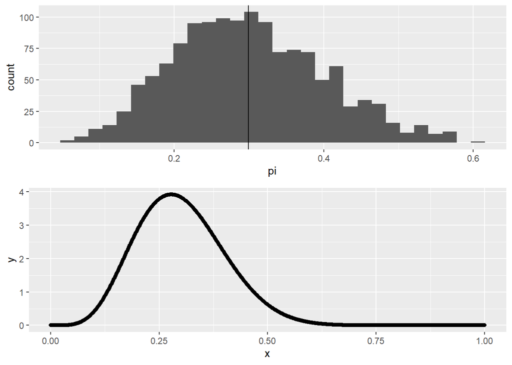

```r
x <- seq(0,1,length.out=1000) # all possible x values
posterior_ci <-tibble(x=x, y=dbeta(x, 3+3,10+7-3)) # posterior model
ci_pr <- ggplot(data=posterior_ci, aes(x,y)) + geom_point()

ggarrange(ci_p, ci_pr, ncol = 1, nrow = 2)
```

```r
## Compare means
tibble(real_mean=mean(posterior_ci$x*posterior_ci$y), simulated_mean=mean(ci_sim_p$pi))
```

```
## # A tibble: 1 x 2
##   real_mean simulated_mean
##       <dbl>          <dbl>
## 1     0.300          0.299
```

Taylor

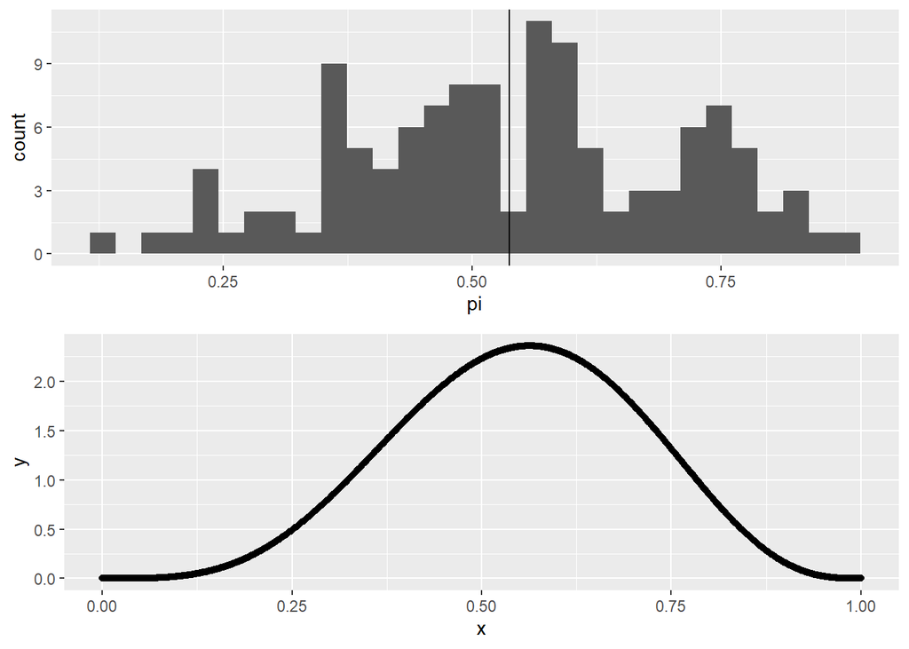

```r
x <- seq(0,1,length.out=1000) # all possible x values
posterior_ty <-tibble(x=x, y=dbeta(x, 2+3,.1+7-3)) # posterior model
ty_pr <- ggplot(data=posterior_ty, aes(x,y)) + geom_point()

ggarrange(ty_p, ty_pr, ncol = 1, nrow = 2)
```

```r
## Compare means
tibble(real_mean=mean(posterior_ty$x*posterior_ty$y), simulated_mean=mean(ty_sim_p$pi))
```

```
## # A tibble: 1 x 2
##   real_mean simulated_mean
##       <dbl>          <dbl>
## 1     0.549          0.537
```

Simulations and real posterior look very similar!

## 4.7

My thought process follows two steps: 1) Estimate the skewness of the beta distribution based on the relationship between alpha and beta. 2) Consider the proportion of the trial and the n size to estimate the likelihood function. 3) Ponder where the posterior model would be according to the shape of both distributions

1. The data has more influence on the posterior
2. The prior has more influence on the posterior
3. The posterior is an equal compromise between the data and the prior
4. The posterior is an equal compromise between the data and the prior
5. The data has more influence on the posterior

## 4.8

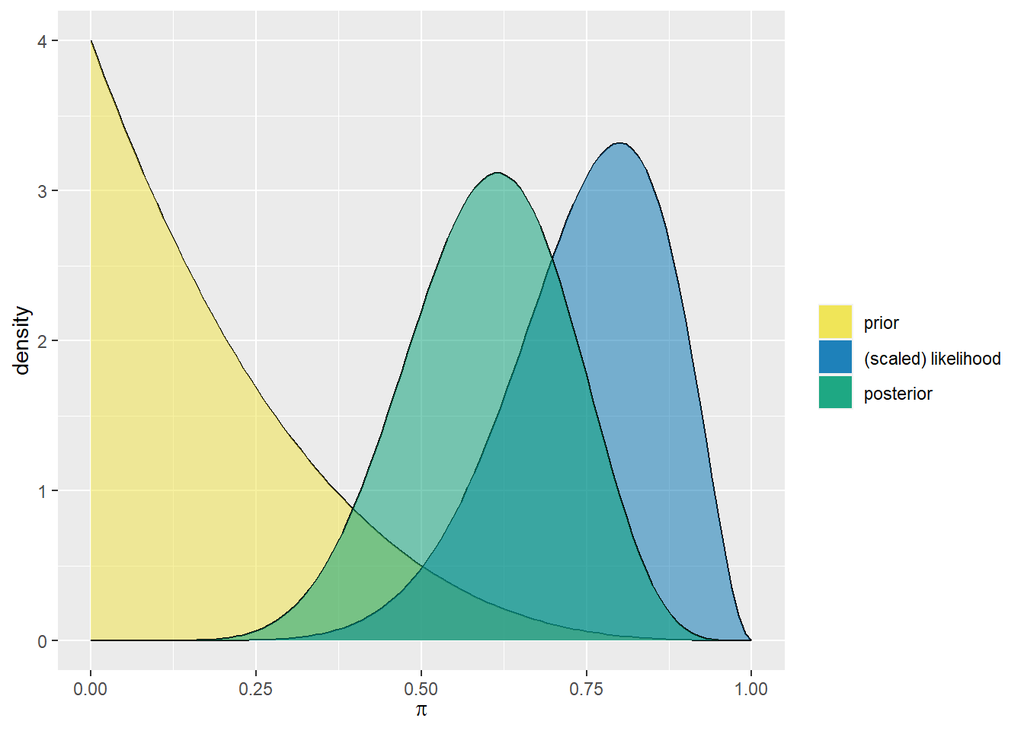

```r
plot_beta_binomial(1,4,8,10)
```

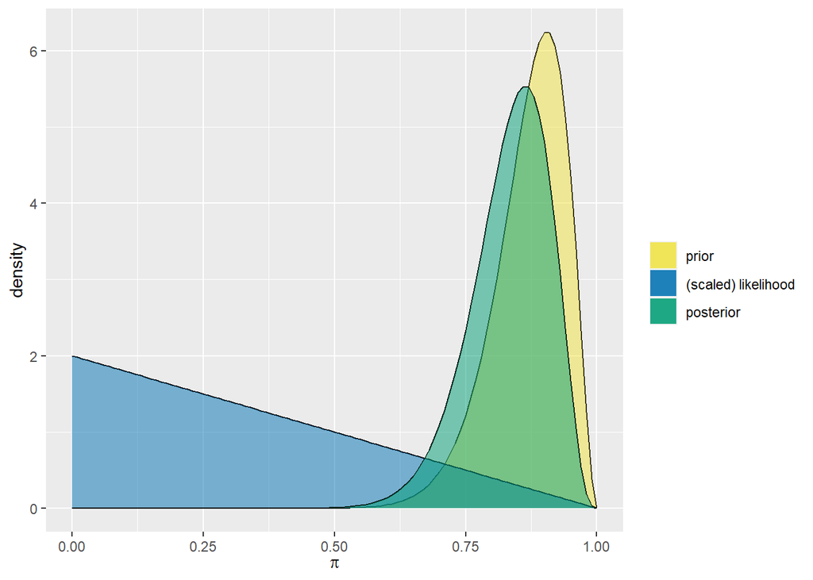

```r
plot_beta_binomial(20,3,0,1)
```

c.

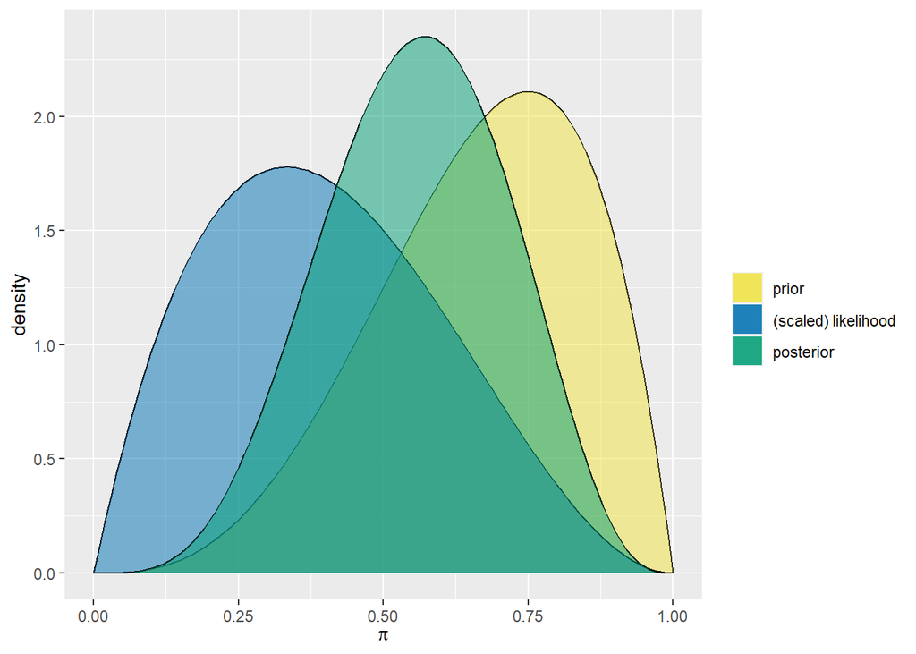

```r
plot_beta_binomial(4,2,1,3)
```

d.

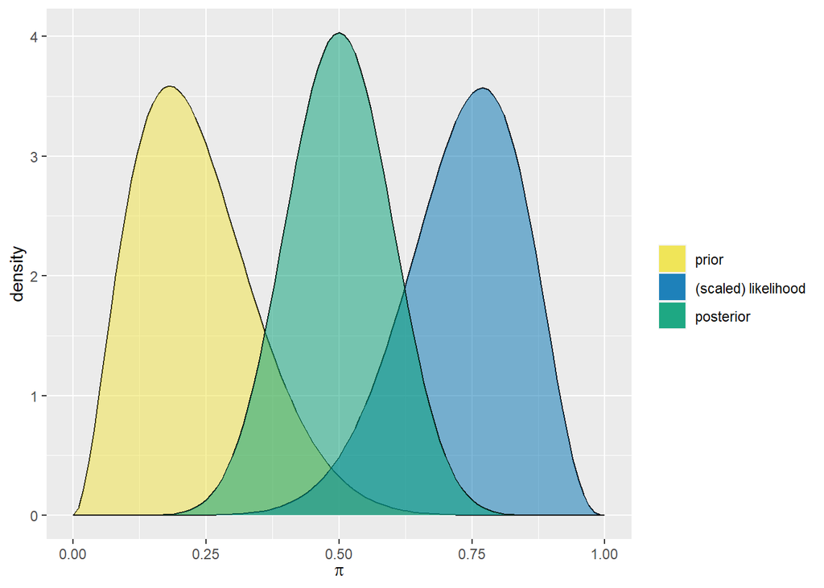

```r
plot_beta_binomial(3,10,10,13)
```

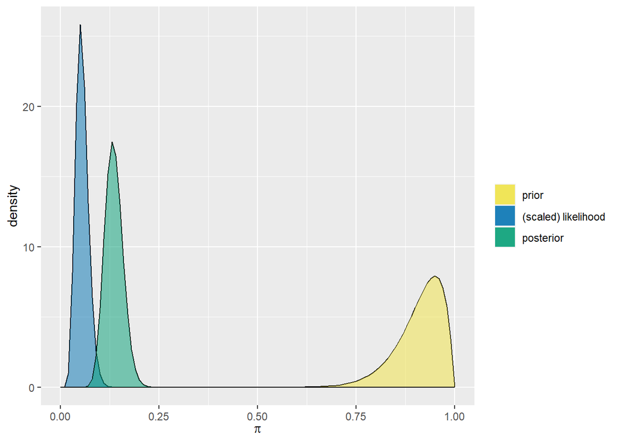

```r
plot_beta_binomial(20,2,10,200)
```

## 4.9

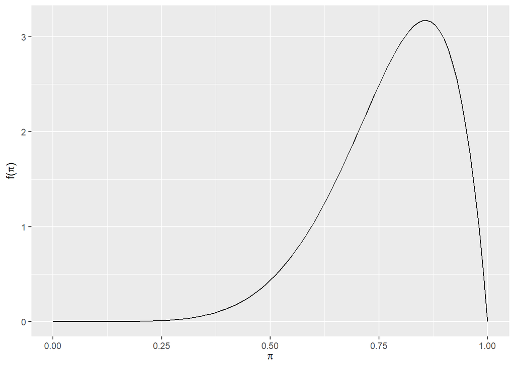

```r
plot_beta(7,2)
```

```r
quantile(rbeta(1000, 7, 2), c(.05,.95))
```

```
##        5%       95%
## 0.5311024 0.9526598
```

```r
mean(rbeta(1000, 7, 2))
```

```
## [1] 0.782597
```

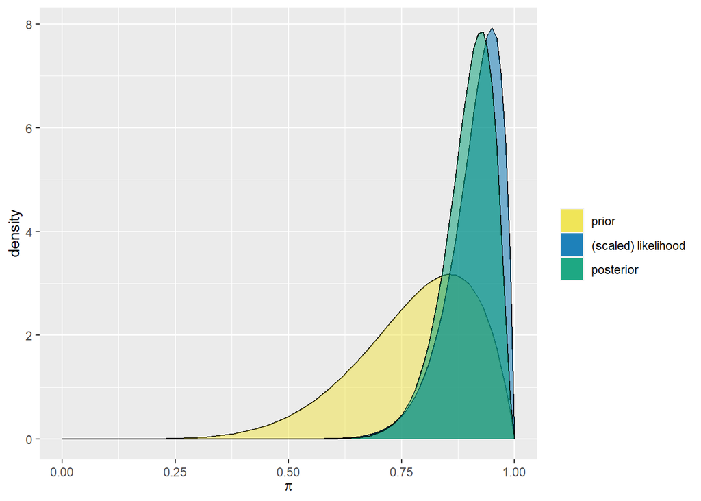

```r
plot_beta_binomial(7,2,19,20)
```

```r
quantile(rbeta(1000, 7+19, 2+20-19), c(.05,.95))
```

```
##        5%       95%
## 0.7884235 0.9695112
```

```r
mean(rbeta(1000, 7+19, 2+20-19))
```

```
## [1] 0.8993412
```

3. The new data would make me reconsider my prior in a meaningful way. The posterior model mean is now .27 in contrast to my initial .8 mean. However, the level of uncertainty is relatively high: 90% of values range from .15 to .42

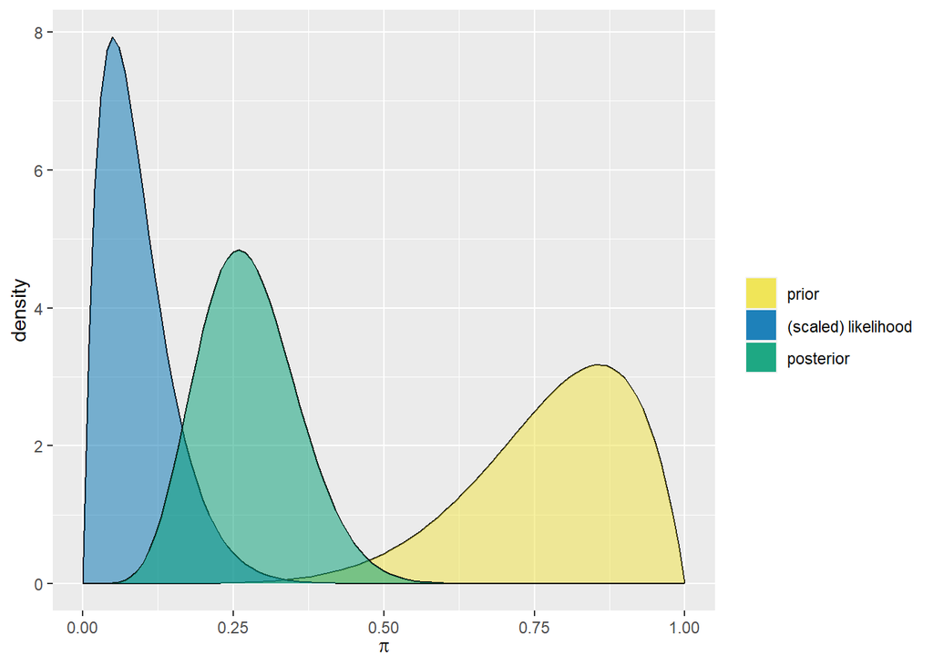

```r
plot_beta_binomial(7,2,1,20)
```

```r
quantile(rbeta(1000, 7+1, 2+20-1), c(.05,.95))
```

```
##        5%       95%
## 0.1501127 0.4205084
```

```r
mean(rbeta(1000, 7+1, 2+20-1))
```

```
## [1] 0.2720446
```

4. The new data has a considerable n size, so that would make me reconsider my prior and push it to the left. The posterior model mean is now .58 in contrast to my initial .8 mean.

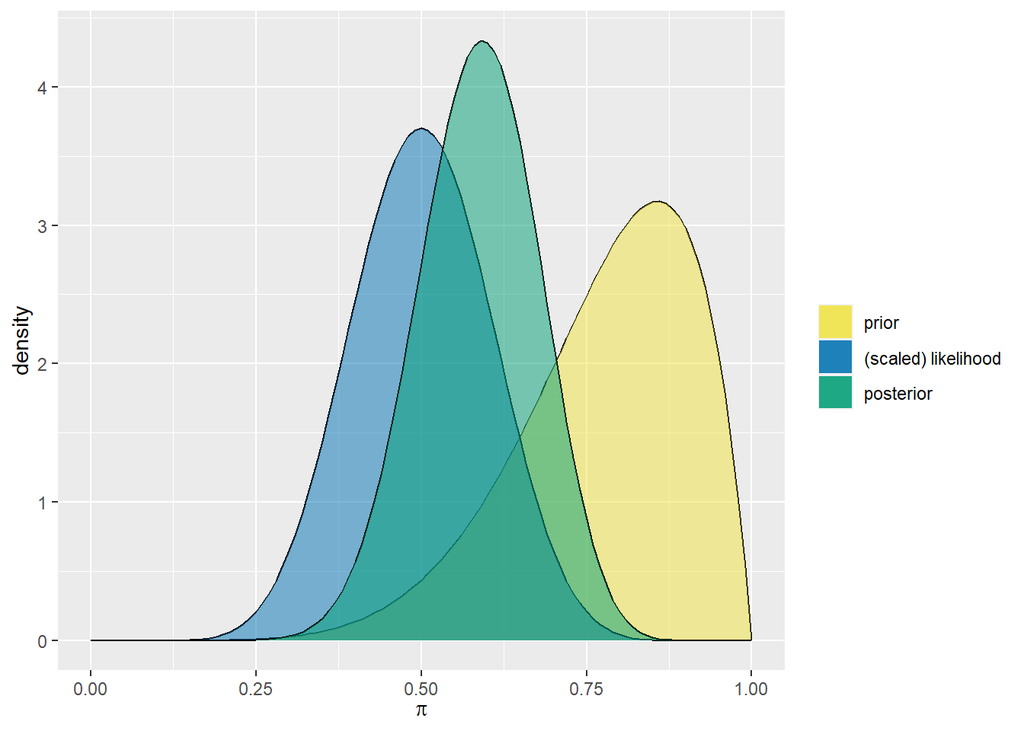

```r
plot_beta_binomial(7,2,10,20)
```

```r
quantile(rbeta(1000, 7+10, 2+20-10), c(.05,.95))
```

```
##        5%       95%
## 0.4385570 0.7290617
```

```r
mean(rbeta(1000, 7+10, 2+20-10))
```

```
## [1] 0.582536
```

## 4.10

We can solve for y and n in the posterior model equation to solve this problems. I will first see the intuition behind it and then compute the numbers.

```r
y_func <- function(poalfa,palfa) {
  result <- poalfa-palfa
  return(result)
}

n_func <- function(pobeta,pbeta,y) {
  result <- pobeta+y-pbeta
  return(result)
}
```

1. We need data that pushes the distribution to the right

```r
pr_alfa <- .5
pr_beta <- .5
pos_alfa <- 8.5
pos_beta <- 2.5
y <- y_func(pos_alfa,pr_alfa)
n <- n_func(pos_beta,pr_beta,y)

y
```

```
## [1] 8
```

```r
n
```

```
## [1] 10
```

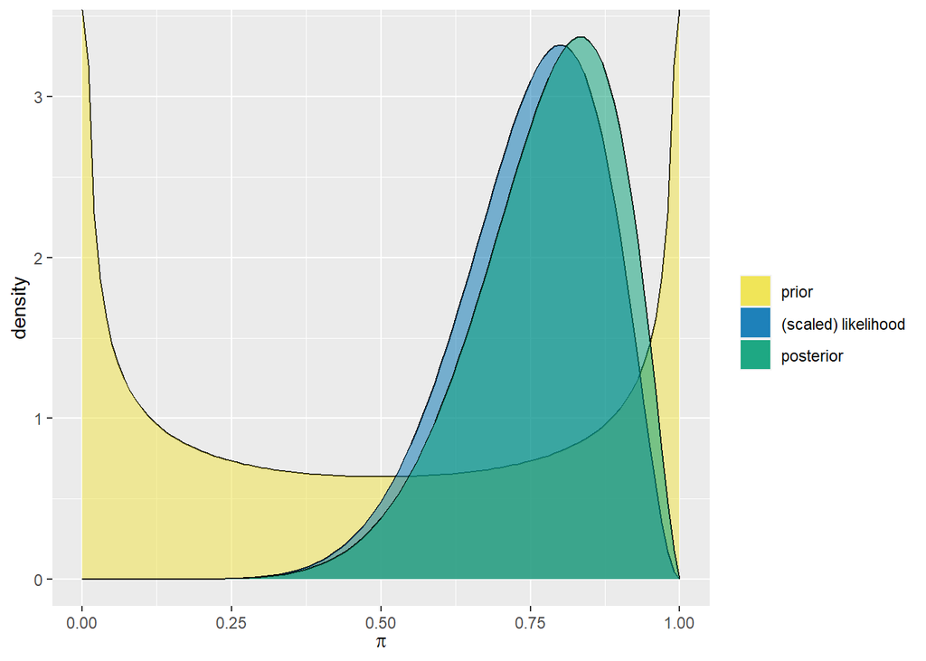

```r
  plot_beta_binomial(pr_alfa,pr_beta,y,n)
```

2. We need data that pushes the distribution to the left

```r
pr_alfa <- .5
pr_beta <- .5
pos_alfa <- 3.5
pos_beta <- 10.5
y <- y_func(pos_alfa,pr_alfa)
n <- n_func(pos_beta,pr_beta,y)

y
```

```
## [1] 3
```

```r
n
```

```
## [1] 13
```

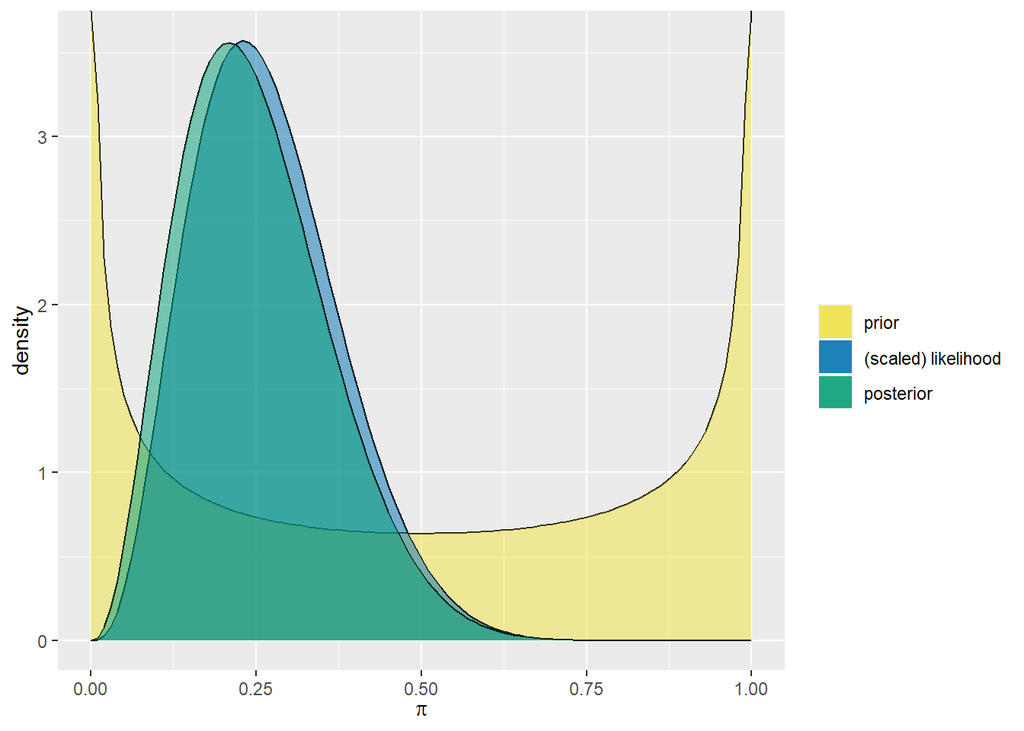

```r
  plot_beta_binomial(pr_alfa,pr_beta,y,n)
```

2. We need data that pushes the posterior distribution to the center. That would require a likelihood function skewed to the left.

```r
pr_alfa <- 10
pr_beta <- 1
pos_alfa <- 12
pos_beta <- 15
y <- y_func(pos_alfa,pr_alfa)
n <- n_func(pos_beta,pr_beta,y)

y
```

```
## [1] 2
```

```r
n
```

```
## [1] 16
```

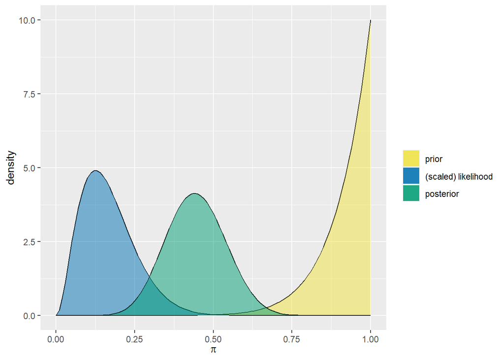

```r
  plot_beta_binomial(pr_alfa,pr_beta,y,n)
```

4. Both the prior and the posterior seem to be skewed to the right due to their large alfas. Thus, we need some data in between.

```r
pr_alfa <- 8
pr_beta <- 3
pos_alfa <- 15
pos_beta <- 6
y <- y_func(pos_alfa,pr_alfa)
n <- n_func(pos_beta,pr_beta,y)

y
```

```
## [1] 7
```

```r
n
```

```
## [1] 10
```

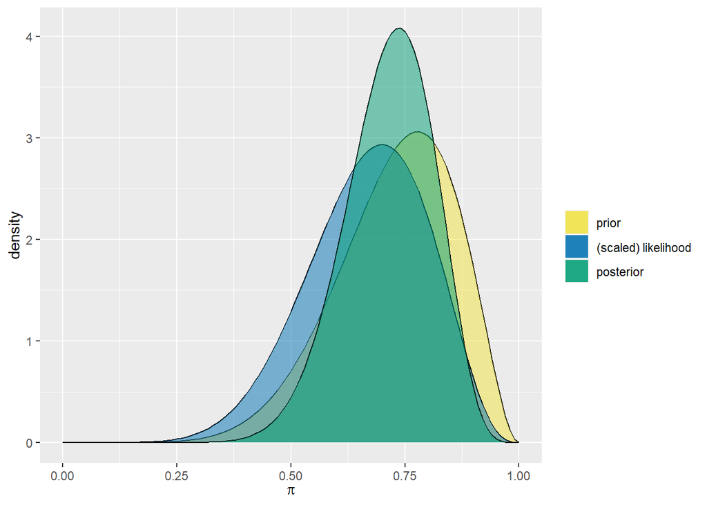

```r
  plot_beta_binomial(pr_alfa,pr_beta,y,n)
```

5. Both the prior and the posterior seem to be have the same mean, so the data should be also close to that mean

```r
pr_alfa <- 2
pr_beta <- 2
pos_alfa <- 5
pos_beta <- 5
y <- y_func(pos_alfa,pr_alfa)
n <- n_func(pos_beta,pr_beta,y)

y
```

```
## [1] 3
```

```r
n
```

```
## [1] 6
```

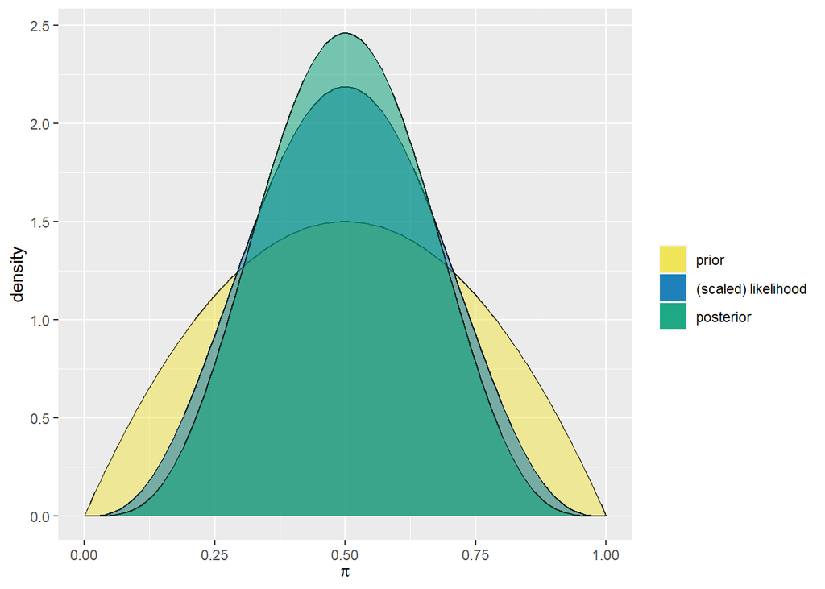

```r
  plot_beta_binomial(pr_alfa,pr_beta,y,n)
```

6. Since the prior follows a uniform distribution, our data can be inferred just based on the posterior, which is very skewed to the right. That means y is very close to n!

```r
pr_alfa <- 1
pr_beta <- 1
pos_alfa <- 30
pos_beta <- 3
y <- y_func(pos_alfa,pr_alfa)
n <- n_func(pos_beta,pr_beta,y)

y
```

```
## [1] 29
```

```r
n
```

```
## [1] 31
```

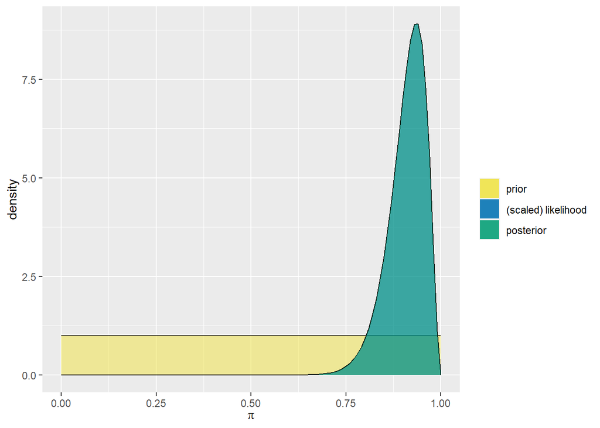

```r
  plot_beta_binomial(pr_alfa,pr_beta,y,n)
```

## 4.11

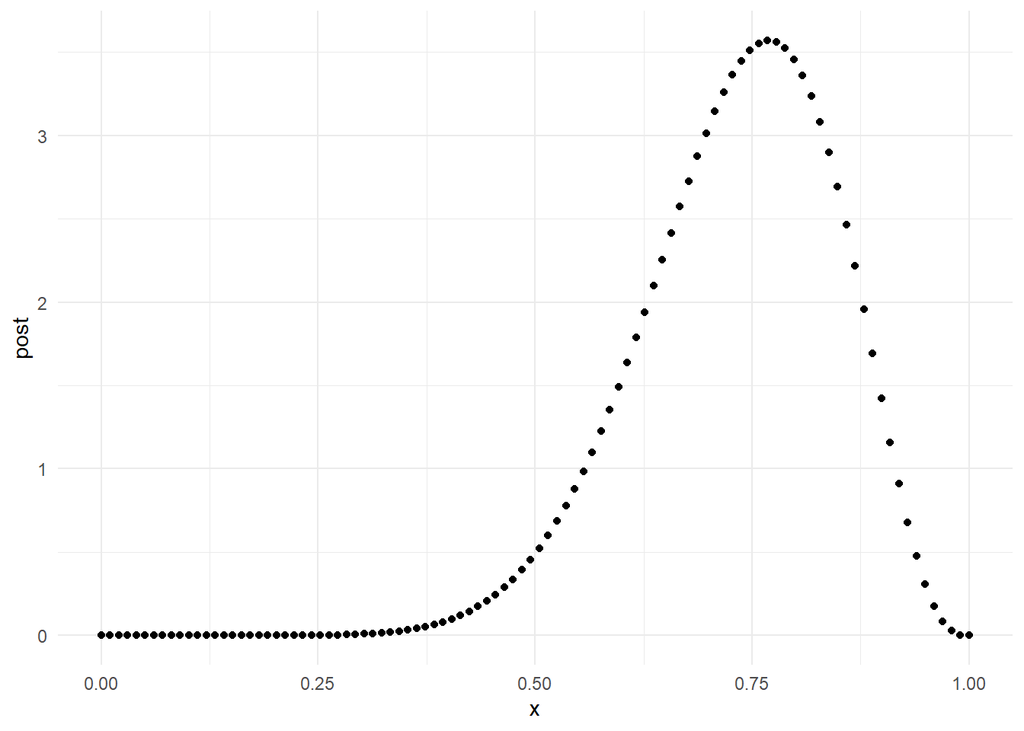

```r
## Set alpha and beta for Beta (1,1)
pr_alfa <- 1
pr_beta <- 1
## Set trials data
y <- 10
n <- 13

x <- seq(0,1,length.out=100)

a_plot <- tibble(x=x, post=dbeta(x, pr_alfa+y,pr_beta+n-y)) |> ggplot(aes(x,post)) + geom_point() + theme_minimal()

a_plot
```

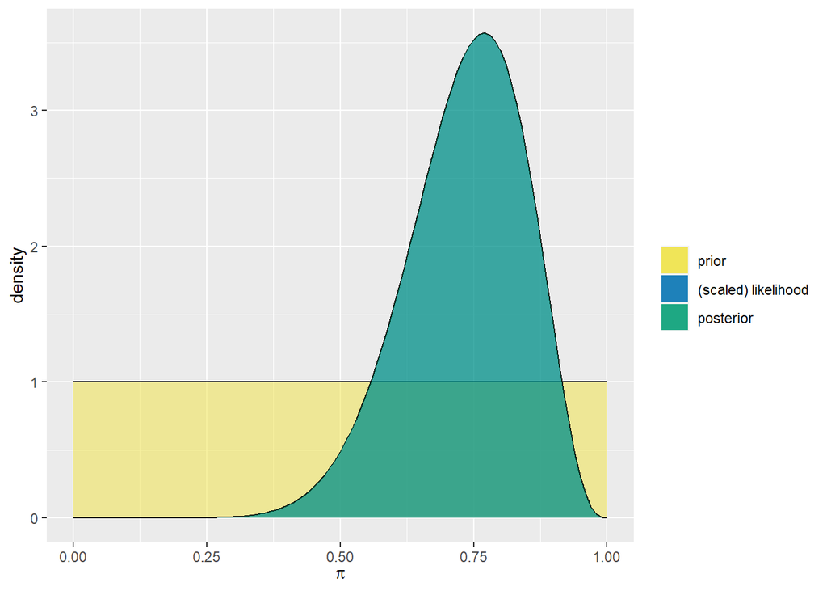

```r
plot_beta_binomial(pr_alfa,pr_beta,y,n)
```

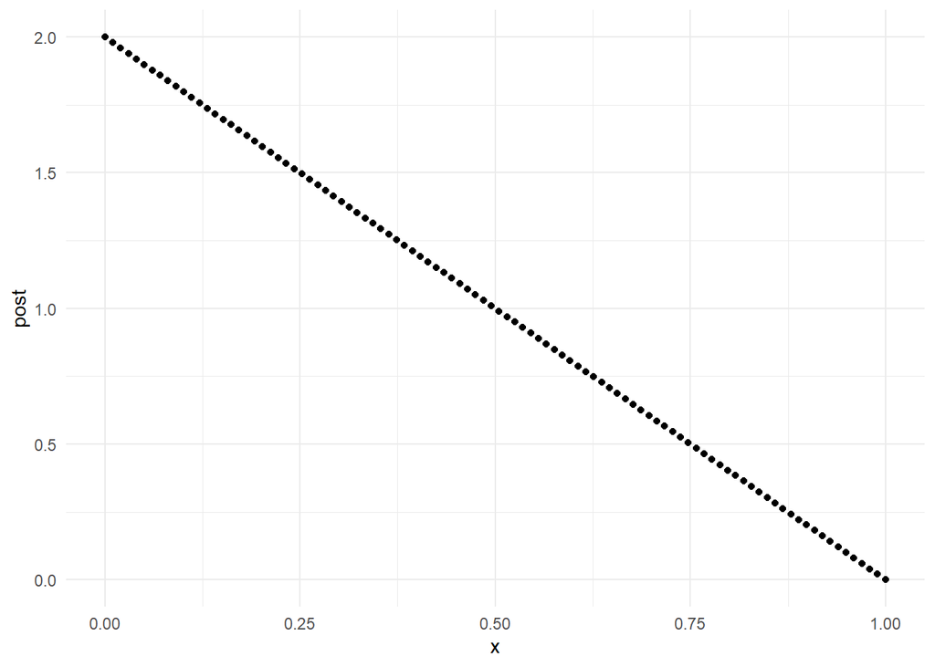

```r
## Set alpha and beta for Beta (1,1)
pr_alfa <- 1
pr_beta <- 1
## Set trials data
y <- 0
n <- 1

x <- seq(0,1,length.out=100)

b_plot <- tibble(x=x, post=dbeta(x, pr_alfa+y,pr_beta+n-y)) |> ggplot(aes(x,post)) + geom_point() + theme_minimal()

b_plot
```